# Evaluating Discards using Observer Data - Guyana`s Shrimp Fishery

Seion Richardson

October 23, 2020

```r
Mas102Discards <- read_csv("observer_weights_mas102m.csv")
```

# 1 FIRST SUBMISSION

## 1.1 Definition of Key terms

**Total catch** - the amount of fish caught by a fishing gear that reaches the vessels deck

**Target catch** - the main species which are sought after by a particular fishery e.g. cod or shrimp

**Incidental catch** - the species caught which are retained for consumption or marketing purposes

**Discarded catch** - the section of catch returned to the sea, usually dead or alive due to economic or legal considerations

**Bycatch** - Discarded catch combined with incidental catch

**Observers** - are specialists trained in collecting data onboard commercial fishing vessels

**Observer data** - data collected at-sea by observers

**Drag** - The act of fishing or trawling

**CPUE** - Catch per unit effort

## 1.2 Data description

The data to be used was amassed by at-sea observers onboard seabob shrimp trawl vessels (2019 to 2020). All of the sampled hauls were collected within the seabob trawling zone i.e. 8 to 18 fathoms water depth (see Figure 1). The dataset generated includes haul-by-haul data for 8 fishing trips with an average of 6 sampled hauls per trip (i.e. 3 days and 3 nights). These were amassed at different fishing locations, fishing depths and by different fishing vessels (split between two fishing companies). Other key variables measured included the time taken for each drag, days-at-sea and GPS co-ordinates for the sampled hauls.

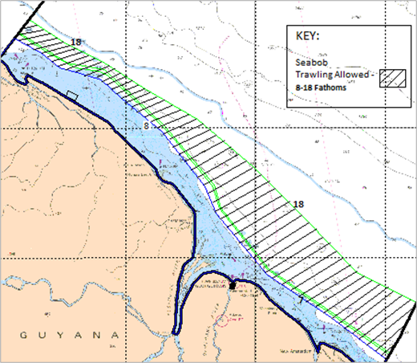

Figure 1: Seabob trawling zone (8 and 18-fathom lines) within the EEZ. Modified from (Maison 2015)

### 1.2.1 Data Variables

The variables within the dataset are coded. A description for each variable is below:

### 1.2.2 First 10 rows from data

```r
Data <- head(Mas102Discards, 10)

kable(Data, "html") %>% kable_styling("striped") %>% scroll_box(width = "100%")
```

| company | dep_date | arr_date | das | trip | drag | drag_all | drag_date | drag_period | drag_time_s | drag_time_e | time_fished_min | hrs_dec | depth | depth_sd | id_status | com_status | order | family | class | total_catch_cat | total_catch_spp | categories | sci_name | alpha_code | com_name | sample_wt_lbs | total_wt_lbs | cpue |
| --- | --- | --- | --- | --- | --- | --- | --- | --- | --- | --- | --- | --- | --- | --- | --- | --- | --- | --- | --- | --- | --- | --- | --- | --- | --- | --- | --- | --- |
| NHS | 14/02/2019 | 24/02/2019 | 11 | 1 | 1 | 1 | 15/02/2019 | Day | 08:00:00 | 12:00:00 | 04:00:00 | 4 | 10 | Deep | Yes | No | Perciformes | Sciaenidae | Actinopterygii | Discarded bycatch | Bycatch species | Bony fish | Paralonchurus brasiliensis | RLB | Banded croaker | 0.50 | 1.26 | 0.3150 |
| NHS | 14/02/2019 | 24/02/2019 | 11 | 1 | 1 | 1 | 15/02/2019 | Day | 08:00:00 | 12:00:00 | 04:00:00 | 4 | 10 | Deep | Yes | Yes | Perciformes | Sciaenidae | Actinopterygii | Discarded bycatch | Bycatch species | Bony fish | Macrodon ancylodon | WKK | Bangamary | 3.00 | 7.58 | 1.8950 |
| NHS | 14/02/2019 | 24/02/2019 | 11 | 1 | 1 | 1 | 15/02/2019 | Day | 08:00:00 | 12:00:00 | 04:00:00 | 4 | 10 | Deep | Yes | No | Decapoda | Malacostraca | Malacostraca | Discarded bycatch | Bycatch species | Shell fish | Hepatus gronovii | HGV | Box crab | 0.70 | 1.77 | 0.4425 |
| NHS | 14/02/2019 | 24/02/2019 | 11 | 1 | 1 | 1 | 15/02/2019 | Day | 08:00:00 | 12:00:00 | 04:00:00 | 4 | 10 | Deep | Yes | Yes | Perciformes | Sciaenidae | Actinopterygii | Discarded bycatch | Bycatch species | Bony fish | Nebris microps | NBM | Butterfish | 3.00 | 7.58 | 1.8950 |
| NHS | 14/02/2019 | 24/02/2019 | 11 | 1 | 1 | 1 | 15/02/2019 | Day | 08:00:00 | 12:00:00 | 04:00:00 | 4 | 10 | Deep | Yes | Yes | Siluriformes | Ariidae | Actinopterygii | Discarded bycatch | Bycatch species | Bony fish | Bagre bagre | BEB | Catfish | 4.30 | 10.87 | 2.7175 |
| NHS | 14/02/2019 | 24/02/2019 | 11 | 1 | 1 | 1 | 15/02/2019 | Day | 08:00:00 | 12:00:00 | 04:00:00 | 4 | 10 | Deep | Yes | Yes | Perciformes | Sciaenidae | Actinopterygii | Discarded bycatch | Bycatch species | Bony fish | Lonchurus elegans | RLE | Chinese butterfish | 6.30 | 15.93 | 3.9825 |
| NHS | 14/02/2019 | 24/02/2019 | 11 | 1 | 1 | 1 | 15/02/2019 | Day | 08:00:00 | 12:00:00 | 04:00:00 | 4 | 10 | Deep | Yes | No | Perciformes | Sciaenidae | Actinopterygii | Discarded bycatch | Bycatch species | Bony fish | Stellifer microps | EFM | Croaker lm | 12.00 | 30.34 | 7.5850 |
| NHS | 14/02/2019 | 24/02/2019 | 11 | 1 | 1 | 1 | 15/02/2019 | Day | 08:00:00 | 12:00:00 | 04:00:00 | 4 | 10 | Deep | Yes | No | Perciformes | Sciaenidae | Actinopterygii | Discarded bycatch | Bycatch species | Bony fish | Stellifer rastrifer | EFR | Croaker rm | 20.00 | 50.57 | 12.6425 |
| NHS | 14/02/2019 | 24/02/2019 | 11 | 1 | 1 | 1 | 15/02/2019 | Day | 08:00:00 | 12:00:00 | 04:00:00 | 4 | 10 | Deep | Yes | No | Pleuronectiformes | Achiridae | Actinopterygii | Discarded bycatch | Bycatch species | Flat fish | Achirus achirus | HIK | Drab sole | 0.75 | 1.90 | 0.4750 |
| NHS | 14/02/2019 | 24/02/2019 | 11 | 1 | 1 | 1 | 15/02/2019 | Day | 08:00:00 | 12:00:00 | 04:00:00 | 4 | 10 | Deep | Yes | Yes | Not applicable | Not applicable | Not applicable | Retained bycatch | Bycatch species | Bony fish | Multiple species finfish | Not applicable | Finfish | 0.00 | 10.83 | 2.7075 |

### 1.2.3 Renaming variables

```r
Mas102Discards <-  Mas102Discards %>% dplyr::rename(Company = company, Departure = dep_date, Arrival = arr_date, DaysAtSea = das, TripID = trip, DragID = drag, DragID2 = drag_all, DragDate = drag_date, DragPeriod = drag_period, DragStart = drag_time_s, DragEnd = drag_time_e, TimeFishedHrs = time_fished_min, TimeFishedDec = hrs_dec, FishingDepth = depth, FishingDepth2 = depth_sd, SpeciesID = id_status, EconomicStatus = com_status, OrderTax = order, FamilyTax = family, ClassTax = class, CatchCategory = total_catch_cat, SpeciesCategory = total_catch_spp, SpeciesCategory2 = categories, LatinNames = sci_name, AplhaCode = alpha_code, CommonName = com_name, SampleWeightLB = sample_wt_lbs, TotalWeightLB = total_wt_lbs, CpueLBHR = cpue)

# A quick view of the new variable names
names(Mas102Discards)
```

```
##  [1] "Company"          "Departure"        "Arrival"          "DaysAtSea"
##  [5] "TripID"           "DragID"           "DragID2"          "DragDate"
##  [9] "DragPeriod"       "DragStart"        "DragEnd"          "TimeFishedHrs"
## [13] "TimeFishedDec"    "FishingDepth"     "FishingDepth2"    "SpeciesID"
## [17] "EconomicStatus"   "OrderTax"         "FamilyTax"        "ClassTax"
## [21] "CatchCategory"    "SpeciesCategory"  "SpeciesCategory2" "LatinNames"
## [25] "AplhaCode"        "CommonName"       "SampleWeightLB"   "TotalWeightLB"
## [29] "CpueLBHR"
```

### 1.2.4 Creating a few additonal variables

Three new variables will be added. These variables will change the the current weight units from **Imperial** to **Metric** which is more common in Europe.

```r
Mas102Discards <- Mas102Discards %>% mutate(SampleWeightKG = SampleWeightLB/2.2, TotalWeightKG = TotalWeightLB/2.2, CpueLBSHR = TotalWeightKG/TimeFishedDec) # Convert from pounds to kilograms

names(Mas102Discards)
```

```
##  [1] "Company"          "Departure"        "Arrival"          "DaysAtSea"
##  [5] "TripID"           "DragID"           "DragID2"          "DragDate"
##  [9] "DragPeriod"       "DragStart"        "DragEnd"          "TimeFishedHrs"
## [13] "TimeFishedDec"    "FishingDepth"     "FishingDepth2"    "SpeciesID"
## [17] "EconomicStatus"   "OrderTax"         "FamilyTax"        "ClassTax"
## [21] "CatchCategory"    "SpeciesCategory"  "SpeciesCategory2" "LatinNames"
## [25] "AplhaCode"        "CommonName"       "SampleWeightLB"   "TotalWeightLB"
## [29] "CpueLBHR"         "SampleWeightKG"   "TotalWeightKG"    "CpueLBSHR"
```

### 1.2.5 Data summary

Here we see the **Mas102Discards** data comprises 1217 observations and 32 variables. The variables were imported as three different class i.e. character (17), difftime (3) and numeric (12). Missing data are contained in the variable **AlphaCode** (75) and this is due unavailability of unique codes for those species. In total 65 species were sampled from the total catch (see **LatinNames** variable). The mean days at sea by fishing vessel was **8 days** with 50% of the vessels spending 7 or less days (Vessels names were not included in the dataset). The average time per drag was 3.88 hrs, with only 25% of the drags being 4 to 5.53 hours.

```r
skim(Mas102Discards)
```

Data summary

| Name | Mas102Discards |
| --- | --- |
| Number of rows | 1217 |
| Number of columns | 32 |
| _______________________ |  |
| Column type frequency: |  |
| character | 17 |
| difftime | 3 |
| numeric | 12 |
| ________________________ |  |
| Group variables | None |

**Variable type: character**

| skim_variable | n_missing | complete_rate | min | max | empty | n_unique | whitespace |
| --- | --- | --- | --- | --- | --- | --- | --- |
| Company | 0 | 1.00 | 3 | 3 | 0 | 2 | 0 |
| Departure | 0 | 1.00 | 10 | 10 | 0 | 8 | 0 |
| Arrival | 0 | 1.00 | 10 | 10 | 0 | 8 | 0 |
| DragDate | 0 | 1.00 | 10 | 10 | 0 | 31 | 0 |
| DragPeriod | 0 | 1.00 | 3 | 5 | 0 | 2 | 0 |
| FishingDepth2 | 0 | 1.00 | 4 | 7 | 0 | 2 | 0 |
| SpeciesID | 0 | 1.00 | 2 | 3 | 0 | 2 | 0 |
| EconomicStatus | 0 | 1.00 | 2 | 3 | 0 | 2 | 0 |
| OrderTax | 0 | 1.00 | 7 | 17 | 0 | 23 | 0 |
| FamilyTax | 0 | 1.00 | 7 | 18 | 0 | 42 | 0 |
| ClassTax | 0 | 1.00 | 7 | 14 | 0 | 8 | 0 |
| CatchCategory | 0 | 1.00 | 12 | 17 | 0 | 3 | 0 |
| SpeciesCategory | 0 | 1.00 | 14 | 15 | 0 | 2 | 0 |
| SpeciesCategory2 | 0 | 1.00 | 5 | 10 | 0 | 4 | 0 |
| LatinNames | 0 | 1.00 | 5 | 26 | 0 | 65 | 0 |
| AplhaCode | 75 | 0.94 | 3 | 14 | 0 | 51 | 0 |
| CommonName | 0 | 1.00 | 4 | 27 | 0 | 79 | 0 |

**Variable type: difftime**

| skim_variable | n_missing | complete_rate | min | max | median | n_unique |
| --- | --- | --- | --- | --- | --- | --- |
| DragStart | 0 | 1 | 4200 secs | 73800 secs | 09:30:00 | 41 |
| DragEnd | 0 | 1 | 1200 secs | 86340 secs | 13:00:00 | 34 |
| TimeFishedHrs | 0 | 1 | 3600 secs | 19920 secs | 03:55:00 | 21 |

**Variable type: numeric**

| skim_variable | n_missing | complete_rate | mean | sd | p0 | p25 | p50 | p75 | p100 | hist |
| --- | --- | --- | --- | --- | --- | --- | --- | --- | --- | --- |
| DaysAtSea | 0 | 1 | 7.69 | 2.00 | 5.00 | 6.00 | 7.00 | 10.00 | 11.00 | ▇▂▂▂▅ |
| TripID | 0 | 1 | 4.56 | 2.24 | 1.00 | 3.00 | 5.00 | 6.00 | 8.00 | ▇▅▇▅▇ |
| DragID | 0 | 1 | 3.45 | 1.70 | 1.00 | 2.00 | 3.00 | 5.00 | 6.00 | ▇▅▃▃▃ |
| DragID2 | 0 | 1 | 24.80 | 13.62 | 1.00 | 13.00 | 26.00 | 36.00 | 48.00 | ▇▆▇▇▇ |
| TimeFishedDec | 0 | 1 | 3.88 | 0.55 | 1.00 | 3.75 | 3.92 | 4.00 | 5.53 | ▁▁▂▇▁ |
| FishingDepth | 0 | 1 | 8.87 | 1.77 | 5.00 | 7.00 | 9.00 | 10.00 | 12.00 | ▂▅▇▇▃ |
| SampleWeightLB | 0 | 1 | 1.93 | 3.91 | 0.00 | 0.10 | 0.43 | 1.70 | 45.00 | ▇▁▁▁▁ |
| TotalWeightLB | 0 | 1 | 33.64 | 76.74 | 0.01 | 4.72 | 18.22 | 31.43 | 1280.00 | ▇▁▁▁▁ |
| CpueLBHR | 0 | 1 | 8.91 | 19.03 | 0.00 | 1.15 | 5.20 | 8.98 | 320.00 | ▇▁▁▁▁ |
| SampleWeightKG | 0 | 1 | 0.88 | 1.78 | 0.00 | 0.05 | 0.20 | 0.77 | 20.45 | ▇▁▁▁▁ |
| TotalWeightKG | 0 | 1 | 15.29 | 34.88 | 0.00 | 2.15 | 8.28 | 14.29 | 581.82 | ▇▁▁▁▁ |
| CpueLBSHR | 0 | 1 | 4.05 | 8.65 | 0.00 | 0.52 | 2.36 | 4.08 | 145.45 | ▇▁▁▁▁ |

## 1.3 Summary of key research variables

This research will look into discard weights, lengths and catch rates (CPUE) and more specifically to measure them against fishing depths and time-periods.

### 1.3.1 Count of species sampled by trip and time-period

```r
Table1 <- Mas102Discards %>%
  filter(CatchCategory == "Discarded bycatch") %>%
  group_by(TripID, DragPeriod) %>%
  dplyr::summarise(Count = n(), .groups = 'drop') %>%
  arrange(TripID)

colnames(Table1) <-c("Trips", "Time-period", "Counts")

Table1 <- Table1 %>%
  flextable() %>%
  autofit(add_w = 1) %>%
  align_text_col(align = "left") %>%
  align_nottext_col(align = "left") %>%
  bg(bg = "#8DD3C7", part = "header") %>%
  color(color = "white", part = "header")  %>%
  set_caption("Count of species sampled across fishing trips and time-periods. Day = 6:00 hrs to 17:59 hrs and Night = 18:00 hrs to 5:59 hrs.  ")
```

[output not shown]

### 1.3.2 Count of species sampled by trip and fishing depth

Here we see that data was across eight fishing trips. The samples were randomly collected across Deep and Shallow water depths. The number of samples collected ranged from 41 (Trip 3 - Shallow) to 177 (Trip 6 - Shallow) with the mean number sampled being 98.

```r
Table2 <- Mas102Discards %>%
  filter(CatchCategory == "Discarded bycatch") %>%
  group_by(TripID, FishingDepth2) %>%
  dplyr::summarise(Count = n(), .groups = 'drop') %>%
   dplyr::arrange(TripID)

colnames(Table2) <-c("Fishing Trips", "Depths (fathoms)", "Counts")

(Table2 <- Table2 %>%
 flextable() %>%
  autofit(add_w = 2) %>%
  align_text_col(align = "left") %>%
  align_nottext_col(align = "left") %>%
  bg(bg = "midnightblue", part = "header") %>%
  color(color = "white", part = "header") %>%
  set_caption("Count of species sampled across fishing trips and dishing depths. Deep = above 9 fathoms and Shallow = equal to or less than 9 fathoms. "))
```

Count of species sampled across fishing trips and dishing depths. Deep = above 9 fathoms and Shallow = equal to or less than 9 fathoms.

| Fishing Trips | Depths (fathoms) | Counts |
| --- | --- | --- |
| 1 | Deep | 86 |
| 1 | Shallow | 42 |
| 2 | Deep | 123 |
| 3 | Deep | 91 |
| 3 | Shallow | 41 |
| 4 | Deep | 71 |
| 4 | Shallow | 45 |
| 5 | Shallow | 145 |
| 6 | Shallow | 177 |
| 7 | Shallow | 138 |
| 8 | Deep | 114 |

## 1.4 Research Questions

### 1.4.1 First Submission

1. What were the species discarded and their relative proportions?
2. What proportions of the total catch were discarded?

### 1.4.2 Second Submission

3. What were the relative weights and catch-rates of the species discarded?
4. Were the weights and catch-rates significantly impacted by time-periods and fishing depth?

### 1.4.3 Third Submission (Joining weight and length data)

5. What were the relative lengths the species discarded?
6. Were the lengths significantly impacted by time-periods and fishing depth?

## 1.5 Species discarded and their relative proportions (Research question 1)

```r
Table3 <- Mas102Discards %>%
  filter(CatchCategory == "Discarded bycatch") %>%
  group_by(OrderTax, FamilyTax, LatinNames) %>%
  dplyr::summarise(n = n(), prop = round(n/48,2), .groups = 'drop') %>%
  arrange(OrderTax)

Table3$OrderTax = ifelse(duplicated(Table3$OrderTax),"",Table3$OrderTax)
Table3$FamilyTax = ifelse(duplicated(Table3$FamilyTax),"",Table3$FamilyTax)

colnames(Table3) <-c("Orders", "Families", "Scientific names", "Counts", "Proportion")

(Table3 <- Table3 %>%
  flextable() %>%
  autofit() %>%
  align_text_col(align = "left") %>%
  align_nottext_col(align = "left") %>%
  bg(bg = "#C90000", part = "header") %>%
  color(color = "white", part = "header") %>%
  color(~ Proportion >= 0.5, ~ Proportion, color = "blue") %>%
  bold(~ Proportion >= 0.5, ~ Proportion, bold = TRUE) %>%
    set_caption("Fish taxa identified from the 48 bottom-trawl hauls sampled off the coast of Guyana. Where p = species presence in proportion within the total samples.Blue fonts  highlights species p of >= 0.5"))
```

Fish taxa identified from the 48 bottom-trawl hauls sampled off the coast of Guyana. Where p = species presence in proportion within the total samples.Blue fonts highlights species p of >= 0.5

| Orders | Families | Scientific names | Counts | Proportion |
| --- | --- | --- | --- | --- |
| Anguilliformes | Muraenidae | Gymnothorax ocellatus | 1 | 0.02 |
|  | Ophichthidae | Ophichthus gomesii | 37 | 0.77 |
| Batrachoidiformes | Batrachoididae | Batrachoides surinamensis | 34 | 0.71 |
|  |  | Porichthys pauciradiatus | 1 | 0.02 |
| Carcharhiniformes | Triakidae | Mustelus higmani | 6 | 0.12 |
| Clupeiformes | Clupeidae | Harengula jaguana | 27 | 0.56 |
|  | Engraulidae | Anchoa mitchilli | 22 | 0.46 |
|  |  | Anchoa spinifer | 18 | 0.38 |
|  |  | Anchoviella lepidentostole | 1 | 0.02 |
| Decapoda | Aethridae | Hepatus pudibundus | 3 | 0.06 |
|  | Calappidae | Calappa sulcata | 1 | 0.02 |
|  | Diogenidae | Clibanarius foresti | 2 | 0.04 |
|  |  | Petrochirus diogenes | 1 | 0.02 |
|  | Inachoididae | Paulita tuberculata | 3 | 0.06 |
|  | Leucosiidae | Persephona lichtensteinii | 21 | 0.44 |
|  | Malacostraca | Hepatus gronovii | 24 | 0.50 |
|  | Portunidae | Callinectes ornatus | 47 | 0.98 |
| Elopiformes | Elopidae | Elops saurus | 1 | 0.02 |
| Lophiiformes | Ogcocephalidae | Ogcocephalus darwini | 1 | 0.02 |
| Myliobatiformes | Dasyatidae | Dasyatis geijskesi | 6 | 0.12 |
|  |  | Dasyatis guttata | 27 | 0.56 |
|  | Gymnuridae | Gymnura micrura | 31 | 0.65 |
|  | Myliobatidae | Rhinoptera bonasus | 3 | 0.06 |
|  | Urotrygonidae | Urotrygon microphthalmum | 13 | 0.27 |
| Orectolobiformes | Ginglymostomatidae | Ginglymostoma cirratum | 1 | 0.02 |
| Paxillosida | Luidiidae | Luidia senegalensis | 1 | 0.02 |
| Pennatulacea | Renillidae | Renilla muelleri | 2 | 0.04 |
| Perciformes | Carangidae | Chloroscombrus chrysurus | 4 | 0.08 |
|  |  | Selene brownii | 20 | 0.42 |
|  | Centropomidae | Centropomus pectinatus | 4 | 0.08 |
|  |  | Centropomus undecimalis | 1 | 0.02 |
|  | Ephippidae | Chaetodipterus faber | 25 | 0.52 |
|  | Haemulidae | Conodon nobilis | 4 | 0.08 |
|  |  | Genyatremus luteus | 10 | 0.21 |
|  | Sciaenidae | Corvula sanctaeluciae | 2 | 0.04 |
|  |  | Cynoscion jamaicensis | 1 | 0.02 |
|  |  | Cynoscion virescens | 44 | 0.92 |
|  |  | Daysciaena albida | 1 | 0.02 |
|  |  | Larimus breviceps | 21 | 0.44 |
|  |  | Lonchurus elegans | 23 | 0.48 |
|  |  | Macrodon ancylodon | 48 | 1.00 |
|  |  | Micropogonias furnieri | 8 | 0.17 |
|  |  | Nebris microps | 29 | 0.60 |
|  |  | Paralonchurus brasiliensis | 38 | 0.79 |
|  |  | Stellifer microps | 45 | 0.94 |
|  |  | Stellifer rastrifer | 47 | 0.98 |
|  | Scombridae | Scomberomorus brasiliensis | 6 | 0.12 |
|  | Serranidae | Epinephelus flavolimbatus | 4 | 0.08 |
|  | Trichiuridae | Trichiurus lepturus | 42 | 0.88 |
| Pleuronectiformes | Achiridae | Achirus achirus | 38 | 0.79 |
|  | Cynoglossidae | Symphurus plagusia | 43 | 0.90 |
| Polymixiiformes | Polymixiidae | Polymixia lowei | 10 | 0.21 |
| Rajiformes |  | Dasyatis geijskesi | 15 | 0.31 |
| Rhinopristiformes | Rhinobatidae | Pseudobatos percellens | 6 | 0.12 |
| Siluriformes | Ariidae | Arius proops | 14 | 0.29 |
|  |  | Bagre bagre | 42 | 0.88 |
| Stomatopoda | Squillidae | Squilla mantis | 34 | 0.71 |
| Tetraodontiformes | Tetraodontidae | Colomesus psittacus | 23 | 0.48 |
|  |  | Sphoeroides testudineus | 14 | 0.29 |
| Teuthida | Loliginidae | Lolliguncula brevis | 10 | 0.21 |
| Torpediniformes | Narcinidae | Narcine brasiliensis | 11 | 0.23 |
| Unknown | Unknown | Scyphozoa sp. | 25 | 0.52 |
|  |  | Un id | 26 | 0.54 |